# Git, github and version control

## Git

- Git is a version control system
- A github repository is a directory that the software git is using to keep track of versions
- Install [git](https://git-scm.com/book/en/v2/Getting-Started-Installing-Git), it's already installed on most cloud services
- You can initialize a repository in a dir with the command `git init` (though we'll present a different workflow later
- Your git repo then is a locally version controlled system

[interactive chart not shown]

### Locally

- Personally, I tend to initialize repos on github, then clone them locally
- If you want to initialize the repo locally, it's as easy as this

```
cd PATH_TO_YOUR_DIRECTORY
git init
```

- Or you can use the graphical utilies

[interactive chart not shown]

### Adding files

- You can add files with the command

  ```
  git add FILENAME
  ```

- The file `FILENAME` is now staged to be part of the repository
- Files that you haven't added won't be tracked
- You only need to add the file once

[interactive chart not shown]

### Checking status

- One of the most useful git commands is

  ```
  git status
  ```

- This gives the status of which files are being tracked, which are not and which have changes

[interactive chart not shown]

### Commiting changes

- You have to actually commit your changes to the repository to have them represented
- Committing changes is a local operation, subsequently, we'll show you how to coordinate with a remote repository
- Here's the command I use to commit most often

  ```
  git commit -a -m "COMMIT MESSAGE"
  ```

- Here the flag `-a` means commit all files staged for commits. You can also commit individual files or a collection of specific files
- The `-m "COMMIT MESSAGE"` is the message associated with your commit. Make your commit messages more informative. If you don't add `-m` github will bring up an editor for you to enter your commit message

[interactive chart not shown]

# Remote repositories

- Git becomes much more useful when it's coordinated with a remote repository
- Github is a server for hosting remote git repositories, there are several others, bitbucket is an example
- Github also includes a great deal of functionality for working with the remote repository through the website
- There's many git and github guis that you could use if you want. I always liked to github one and magit in emacs

[interactive chart not shown]

## Connecting your remote and local repos

- You need to connect your local repo to the remote repo
- First create a version of the repo on github (actually then it gives you instructions)
- Then you can either
  1. *Clone* the repo from the server `git clone REMOTE SERVER`
  2. Connect the server to your local repository

     ```
     git remote add origin git@github.com:USERNAME/REPONAME.git
     ```

- Personally, I find it easier just to create the repo on github and clone it
- You can clone over ssh or https, if you don't know what ssh is use https

[interactive chart not shown]

## Pushing changes

- You push from the repo you're working on to another (remote repo). So, for me, typically pushing from my computer repo to github

  ```
  git push origin main
  ```

  which could be read as "push my new committed changes from my origin to the main branch on my remote repo".
- Older repos had the default branch `master` instead of `main`. But, github switched in 2020 or so

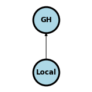

[interactive chart not shown]

## Pulling changes

- There might be changes that you want represented locally that were changed on the remote repository; for example, you might edit a readme file through github's web interface
- The command for this is really easy, it's just pull

  ```
  git pull
  ```

- The pain occurs if you have made local changes that are in conflict with the remote changes
- [Here's some docs on managing merge conflicts](https://docs.github.com/en/pull-requests/collaborating-with-pull-requests/addressing-merge-conflicts/resolving-a-merge-conflict-using-the-command-line)

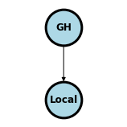

[interactive chart not shown]

## Cloning

- To clone a remote repository is simply to copy it locally
- If a repository is public
  - If you own it, then you can clone it and push changes back to the remote
  - If you don't, you can clone and pull changes, but then can't push back to the remote
    - Try with the course repo, clone it so you have access to the files
    - In the figure below the owner can pull and push to the repo
- In the picture below, consider that you clone GH1 off of github to you. You can pull updates from GH1 but can't push changes to GH1. The owner of GH1 of course can pull and push

```
git clone https://github.com/smart-stats/ds4bio_book.git
```

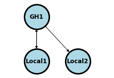

[interactive chart not shown]

## Forking

- A common workflow for github is to "fork" the repository. This differs from cloning in the sense that your fork is an entirely separate new copy
- In the picture below, GH2 is a fork of GH1. It can pull upstream changes from GH1, but can't write to it, since you don't own that repo. You can push and pull from Local2 which is connected to GH2.

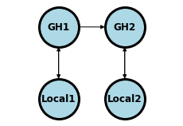

[interactive chart not shown]

## Pull requests

- If you want your changes represented in GH1, recall you don't have write access to that repo
  - Example, you forked this repo and have great additions and changes you think should be represented for other students
  - You issue a *pull request* in the sense of requesting GH1 to pull your changes from GH2
  - I can then decide whether or not I'd like those changes pulled into my GH1 repo
- I like to do pull requests directly on github through the web interface

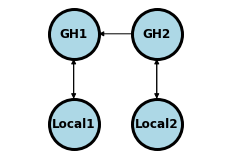

[interactive chart not shown]

## Branching

- You often want multiple version of a repository
  - Example a development version, a working version and a stable version
- This is what branches are for in git

  ```
  git checkout -b dev
  ```

  creates a branch called `dev` and switches to that branch. If you already have `dev`, use `checkout` without `-b`
- Suppose you want to merge your change from `dev` into your default branch (`main`)

  ```
  git checkout main
  git merge dev
  ```

- Start very basic with branches, then when you get the hang of it you can use it like a pro
- [Here's documentation](https://git-scm.com/book/en/v2/Git-Branching-Basic-Branching-and-Merging)

[interactive chart not shown]